# Projet Statistique : Analyse des données médicales

16/12/2025

# 1 . Introduction

## 1.1 . Contexte

Ce projet porte sur un jeu de **données médicales** contenant des informations sur des patients :  
- caractéristiques démographiques (âge, sexe, poids),  
- indicateurs cliniques (tension artérielle, cholestérol),  
- informations de suivi (groupe de traitement, durée de suivi),  
- et un **score de symptômes** résumant l’état de santé.

## 1.2 . Problématique

> Les caractéristiques cliniques (âge, poids, tension, cholestérol, etc.) influencent-elles significativement  
> l’état de santé des patients, mesuré par le **score de symptômes** ?

## 1.3 . Objectifs

- 🔹 **Analyse descriptive** : décrire les variables (statistiques de base, graphiques).
- 🔹 **Analyse univariée** : étudier séparément chaque variable.
- 🔹 **Analyse bivariée** : explorer les relations deux à deux (corrélations, comparaisons de groupes).
- 🔹 **Analyse multivariée** : construire un **modèle explicatif** du score de symptômes.
- 🔹 Fournir des **interprétations claires** et exploitables.

# 2 . Méthodologie et données

## 2.1 . Chargement des packages

```r
required_packages <- c(
  "tidyverse",
  "skimr",
  "GGally",
  "psych",
  "broom",
  "car"
)

installed <- rownames(installed.packages())
for (p in required_packages) {
  if (!p %in% installed) {
    install.packages(p, dependencies = TRUE)
  }
}

library(tidyverse)
library(skimr)
library(GGally)
library(psych)
library(broom)
library(car)
library(dplyr)
library(ggplot2)
```

## 2.2 . Importation du jeu de données

```r
data <- read.csv(
  "patients_medical_data.csv",
  sep = ";",
  header = TRUE,
  stringsAsFactors = FALSE,
  na.strings = c("", "NA", "NaN", "NULL", "?")
)

# Aperçu des premières lignes
head(data)
```

```
##   ID Age Sexe Poids Tension Cholesterol Groupe_Traitement Suivi_Jours
## 1  1  63    F  48.0     130         188                 B          20
## 2  2  76    F  83.4     136         193                 B          20
## 3  3  53    M  68.4     128         200                 B          27
## 4  4  39    F  55.7     143         207                 B          21
## 5  5  67    F  63.8     150         171                 B          27
## 6  6  32    F  49.0     110          NA                 B          26
##   Symptom_Score
## 1             6
## 2             8
## 3             1
## 4            10
## 5             4
## 6             1
```

```r
# Structure des données
str(data)
```

```
## 'data.frame':    100 obs. of  9 variables:
##  $ ID               : int  1 2 3 4 5 6 7 8 9 10 ...
##  $ Age              : int  63 76 53 39 67 32 45 63 43 47 ...
##  $ Sexe             : chr  "F" "F" "M" "F" ...
##  $ Poids            : num  48 83.4 68.4 55.7 63.8 49 64.8 81.3 65.1 57.1 ...
##  $ Tension          : num  130 136 128 143 150 110 143 136 130 106 ...
##  $ Cholesterol      : num  188 193 200 207 171 NA 181 249 NA 242 ...
##  $ Groupe_Traitement: chr  "B" "B" "B" "B" ...
##  $ Suivi_Jours      : int  20 20 27 21 27 26 29 29 21 25 ...
##  $ Symptom_Score    : int  6 8 1 10 4 1 8 1 3 4 ...
```

## 2.3 . Préparation et typage des variables

On suppose les variables suivantes (adapte si besoin à ton dataset) :

```r
data <- data %>%
  mutate(
    Sexe = as.factor(Sexe),
    Groupe_Traitement = as.factor(Groupe_Traitement)
  )

# Vérification des types
str(data)
```

```
## 'data.frame':    100 obs. of  9 variables:
##  $ ID               : int  1 2 3 4 5 6 7 8 9 10 ...
##  $ Age              : int  63 76 53 39 67 32 45 63 43 47 ...
##  $ Sexe             : Factor w/ 2 levels "F","M": 1 1 2 1 1 1 2 2 2 2 ...
##  $ Poids            : num  48 83.4 68.4 55.7 63.8 49 64.8 81.3 65.1 57.1 ...
##  $ Tension          : num  130 136 128 143 150 110 143 136 130 106 ...
##  $ Cholesterol      : num  188 193 200 207 171 NA 181 249 NA 242 ...
##  $ Groupe_Traitement: Factor w/ 2 levels "A","B": 2 2 2 2 2 2 2 2 2 2 ...
##  $ Suivi_Jours      : int  20 20 27 21 27 26 29 29 21 25 ...
##  $ Symptom_Score    : int  6 8 1 10 4 1 8 1 3 4 ...
```

## 2.4 . Gestion des valeurs manquantes

```r
# Nombre de NA par variable
colSums(is.na(data))
```

```
##                ID               Age              Sexe             Poids
##                 0                 0                 0                10
##           Tension       Cholesterol Groupe_Traitement       Suivi_Jours
##                10                10                 0                 0
##     Symptom_Score
##                 0
```

```r
# Proportion de NA par variable
sapply(data, function(x) mean(is.na(x)))
```

```
##                ID               Age              Sexe             Poids
##               0.0               0.0               0.0               0.1
##           Tension       Cholesterol Groupe_Traitement       Suivi_Jours
##               0.1               0.1               0.0               0.0
##     Symptom_Score
##               0.0
```

Interprétation :  
- Si le pourcentage de NA est **faible (< 5%)**, on peut souvent se permettre de **supprimer** les lignes incomplètes.  
- Si le pourcentage est **important**, il faudra envisager une **imputation** (moyenne, médiane, etc.).

```r
#  imputation avec median pour une valeur manquante

data_clean <- data %>%
  mutate(
    Poids       = ifelse(is.na(Poids),       median(Poids, na.rm = TRUE),       Poids),
    Tension     = ifelse(is.na(Tension),     median(Tension, na.rm = TRUE),     Tension),
    Cholesterol = ifelse(is.na(Cholesterol), median(Cholesterol, na.rm = TRUE), Cholesterol)
  )

# Vérification :  aucun NA
colSums(is.na(data_clean))
```

```
##                ID               Age              Sexe             Poids
##                 0                 0                 0                 0
##           Tension       Cholesterol Groupe_Traitement       Suivi_Jours
##                 0                 0                 0                 0
##     Symptom_Score
##                 0
```

> Nous avons imputés les valeurs manquantes par mediane

## 2.5 . Gestion des valeurs doublons

```r
# Vérification du nombre de doublons complets (lignes identiques à 100%)
nb_doublons <- sum(duplicated(data) | duplicated(data, fromLast = TRUE))
cat("Nombre de lignes en doublon complet :", nb_doublons, "\n")
```

```
## Nombre de lignes en doublon complet : 0
```

## 2.6 . Gestion des valeurs aberrante

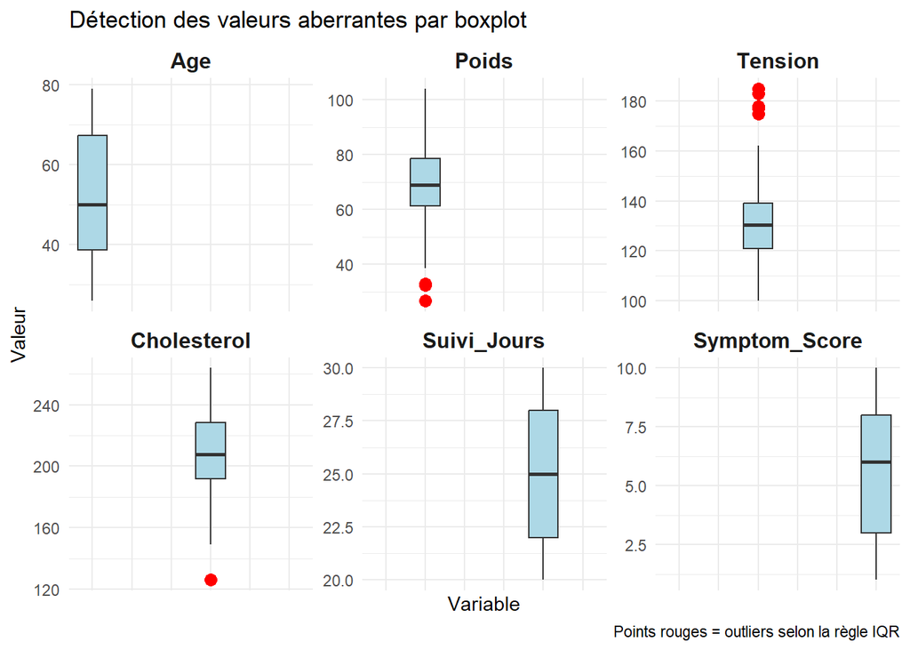

```r
# Variables dans l'ordre que tu veux afficher
vars_quant <- c("Age", "Poids", "Tension", "Cholesterol", "Suivi_Jours", "Symptom_Score")

data_clean %>%
  select(all_of(vars_quant)) %>%
  pivot_longer(everything(), names_to = "Variable", values_to = "Valeur") %>%
  # Ici la clé : on transforme Variable en factor avec l'ordre désiré
  mutate(Variable = factor(Variable, levels = vars_quant)) %>%
  ggplot(aes(x = Variable, y = Valeur)) +
  geom_boxplot(fill = "lightblue", outlier.colour = "red", outlier.size = 3) +
  facet_wrap(~ Variable, scales = "free_y", ncol = 3) +
  theme_minimal() +
  theme(
    axis.text.x = element_blank(),
    axis.ticks.x = element_blank(),
    strip.text = element_text(size = 12, face = "bold")
  ) +
  labs(
    title = "Détection des valeurs aberrantes par boxplot",
    caption = "Points rouges = outliers selon la règle IQR"
  )
```

```r
vars_quant <- c("Age", "Poids", "Tension", "Cholesterol", "Suivi_Jours", "Symptom_Score")

# Fonction pour détecter les outliers (méthode IQR)
detect_outliers <- function(x) {
  Q1 <- quantile(x, 0.25, na.rm = TRUE)
  Q3 <- quantile(x, 0.75, na.rm = TRUE)
  IQR <- Q3 - Q1
  lower <- Q1 - 1.5 * IQR
  upper <- Q3 + 1.5 * IQR
  which(x < lower | x > upper)
}

# Comptage des outliers par variable
outliers_count <- sapply(data_clean[vars_quant], function(x) length(detect_outliers(x)))
outliers_count
```

```
##           Age         Poids       Tension   Cholesterol   Suivi_Jours
##             0             3             5             1             0
## Symptom_Score
##             0
```

```r
# Visualisation avec boxplots
data_clean_long <- data_clean %>%
  select(all_of(vars_quant)) %>%
  pivot_longer(everything(), names_to = "Variable", values_to = "Valeur")

ggplot(data_clean_long, aes(x = Variable, y = Valeur)) +
  geom_boxplot(fill = "lightblue", outlier.colour = "red", outlier.size = 3) +
  theme_minimal() +
  labs(title = "Boxplots des variables quantitatives (détection des outliers)",
       subtitle = "Méthode IQR × 1.5") +
  theme(axis.text.x = element_text(angle = 45, hjust = 1))
```

[figure not shown]

# 3 . Analyse descriptive et univariée

## 3.1 . Résumé global des données

```r
skim(data_clean)
```

Data summary

| Name | data_clean |
| --- | --- |
| Number of rows | 100 |
| Number of columns | 9 |
| _______________________ |  |
| Column type frequency: |  |
| factor | 2 |
| numeric | 7 |
| ________________________ |  |
| Group variables | None |

**Variable type: factor**

| skim_variable | n_missing | complete_rate | ordered | n_unique | top_counts |
| --- | --- | --- | --- | --- | --- |
| Sexe | 0 | 1 | FALSE | 2 | M: 62, F: 38 |
| Groupe_Traitement | 0 | 1 | FALSE | 2 | A: 58, B: 42 |

**Variable type: numeric**

| skim_variable | n_missing | complete_rate | mean | sd | p0 | p25 | p50 | p75 | p100 | hist |
| --- | --- | --- | --- | --- | --- | --- | --- | --- | --- | --- |
| ID | 0 | 1 | 50.50 | 29.01 | 1.0 | 25.75 | 50.5 | 75.25 | 100.0 | ▇▇▇▇▇ |
| Age | 0 | 1 | 52.05 | 16.26 | 26.0 | 38.75 | 50.0 | 67.25 | 79.0 | ▇▇▅▇▇ |
| Poids | 0 | 1 | 69.34 | 14.78 | 26.8 | 61.30 | 68.9 | 78.52 | 104.1 | ▁▃▇▅▂ |
| Tension | 0 | 1 | 131.92 | 17.67 | 100.0 | 121.00 | 130.5 | 139.00 | 185.0 | ▃▇▅▂▁ |
| Cholesterol | 0 | 1 | 207.58 | 27.07 | 126.0 | 192.00 | 207.5 | 228.25 | 264.0 | ▁▂▇▅▃ |
| Suivi_Jours | 0 | 1 | 24.83 | 3.34 | 20.0 | 22.00 | 25.0 | 28.00 | 30.0 | ▇▃▃▃▅ |
| Symptom_Score | 0 | 1 | 5.78 | 2.79 | 1.0 | 3.00 | 6.0 | 8.00 | 10.0 | ▆▇▇▇▇ |

Interprétation :  
- Les tableaux affichent les **statistiques descriptives** (min, max, moyenne, médiane, etc.) pour les variables quantitatives,  
et les **effectifs** pour les variables qualitatives.

## 3.2 . Variables quantitatives

On considère ici : `Age`, `Poids`, `Tension`, `Cholesterol`, `Suivi_Jours`, `Symptom_Score`.

```r
numeric_vars <- data_clean %>%
  select(Age, Poids, Tension, Cholesterol, Suivi_Jours, Symptom_Score)

summary(numeric_vars)
```

```
##       Age            Poids           Tension       Cholesterol
##  Min.   :26.00   Min.   : 26.80   Min.   :100.0   Min.   :126.0
##  1st Qu.:38.75   1st Qu.: 61.30   1st Qu.:121.0   1st Qu.:192.0
##  Median :50.00   Median : 68.90   Median :130.5   Median :207.5
##  Mean   :52.05   Mean   : 69.34   Mean   :131.9   Mean   :207.6
##  3rd Qu.:67.25   3rd Qu.: 78.53   3rd Qu.:139.0   3rd Qu.:228.2
##  Max.   :79.00   Max.   :104.10   Max.   :185.0   Max.   :264.0
##   Suivi_Jours    Symptom_Score
##  Min.   :20.00   Min.   : 1.00
##  1st Qu.:22.00   1st Qu.: 3.00
##  Median :25.00   Median : 6.00
##  Mean   :24.83   Mean   : 5.78
##  3rd Qu.:28.00   3rd Qu.: 8.00
##  Max.   :30.00   Max.   :10.00
```

```r
psych::describe(numeric_vars)
```

```
##               vars   n   mean    sd median trimmed   mad   min   max range
## Age              1 100  52.05 16.26   50.0   52.04 20.76  26.0  79.0  53.0
## Poids            2 100  69.34 14.78   68.9   69.53 12.53  26.8 104.1  77.3
## Tension          3 100 131.92 17.67  130.5  130.52 14.08 100.0 185.0  85.0
## Cholesterol      4 100 207.58 27.07  207.5  208.43 26.69 126.0 264.0 138.0
## Suivi_Jours      5 100  24.83  3.34   25.0   24.79  4.45  20.0  30.0  10.0
## Symptom_Score    6 100   5.78  2.79    6.0    5.82  2.97   1.0  10.0   9.0
##                skew kurtosis   se
## Age            0.05    -1.30 1.63
## Poids         -0.17     0.37 1.48
## Tension        0.80     0.80 1.77
## Cholesterol   -0.31    -0.06 2.71
## Suivi_Jours    0.08    -1.37 0.33
## Symptom_Score -0.12    -1.16 0.28
```

### 3.2.1 . Histogrammes et boxplots

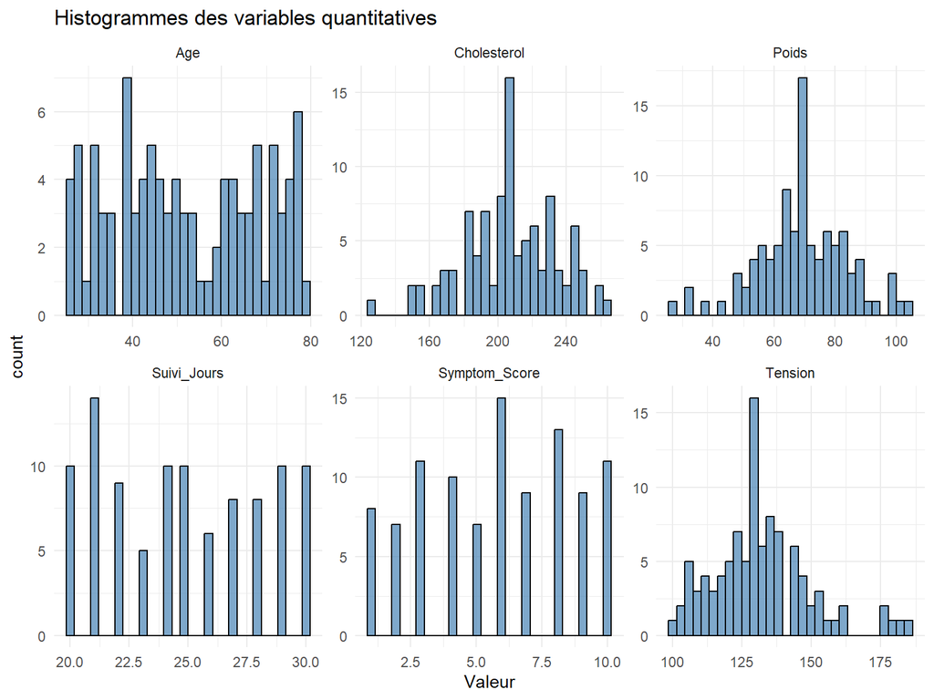

```r
numeric_vars_long <- data_clean %>%
  select(Age, Poids, Tension, Cholesterol, Suivi_Jours, Symptom_Score) %>%
  pivot_longer(cols = everything(), names_to = "Variable", values_to = "Valeur")

ggplot(numeric_vars_long, aes(x = Valeur)) +
  geom_histogram(bins = 30, color = "black", fill = "steelblue", alpha = 0.7) +
  facet_wrap(~ Variable, scales = "free") +
  theme_minimal() +
  labs(title = "Histogrammes des variables quantitatives")
```

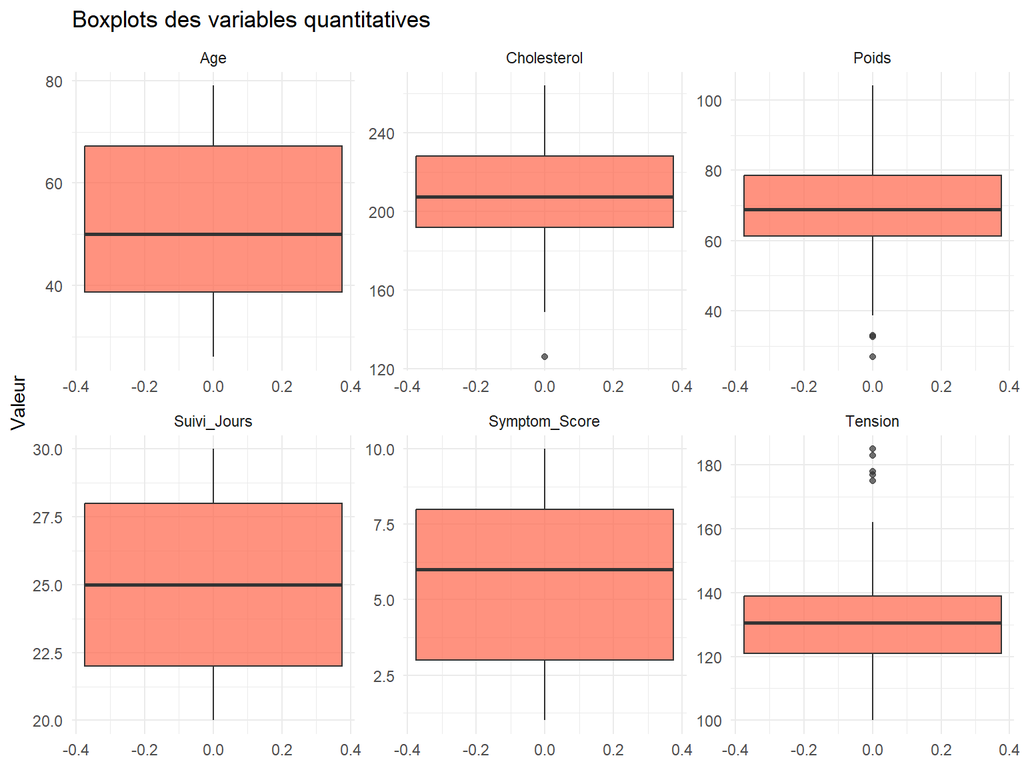

```r
ggplot(numeric_vars_long, aes(y = Valeur)) +
  geom_boxplot(fill = "tomato", alpha = 0.7) +
  facet_wrap(~ Variable, scales = "free") +
  theme_minimal() +
  labs(title = "Boxplots des variables quantitatives")
```

Interprétation :  
- Les histogrammes permettent de voir si les distributions sont **symétriques** ou **asymétriques**.  
- Les boxplots mettent en évidence d’éventuels **outliers** (valeurs extrêmes).

### 3.2.2 . Test de normalité (Shapiro-Wilk)

```r
apply(numeric_vars, 2, function(x) {
  shapiro.test(x)$p.value
})
```

```
##           Age         Poids       Tension   Cholesterol   Suivi_Jours
##  2.931067e-04  3.201787e-01  9.147264e-04  4.198539e-01  1.418544e-05
## Symptom_Score
##  2.223518e-04
```

Interprétation :  
- Si le **p-value < 0,05**, on rejette l’hypothèse de normalité pour la variable.  
- Si le **p-value ≥ 0,05**, la normalité est compatible avec les données.

## 3.3 3.3 Variables qualitatives

On s’intéresse ici à `Sexe` et `Groupe_Traitement`.

```r
table(data_clean$Sexe)
```

```
##
##  F  M
## 38 62
```

```r
prop.table(table(data_clean$Sexe))
```

```
##
##    F    M
## 0.38 0.62
```

```r
table(data_clean$Groupe_Traitement)
```

```
##
##  A  B
## 58 42
```

```r
prop.table(table(data_clean$Groupe_Traitement))
```

```
##
##    A    B
## 0.58 0.42
```

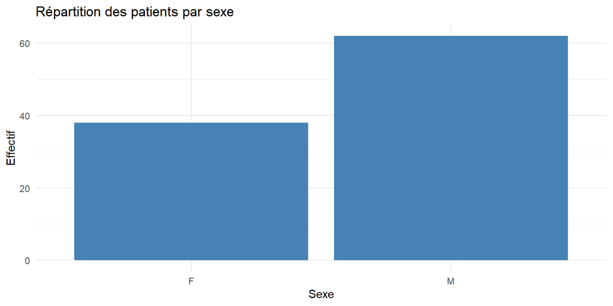

```r
ggplot(data_clean, aes(x = Sexe)) +
  geom_bar(fill = "steelblue") +
  theme_minimal() +
  labs(title = "Répartition des patients par sexe", x = "Sexe", y = "Effectif")
```

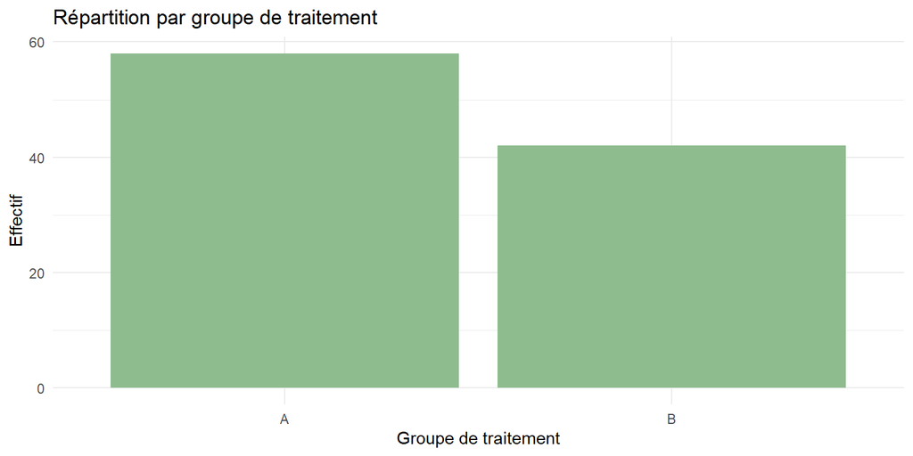

```r
ggplot(data_clean, aes(x = Groupe_Traitement)) +
  geom_bar(fill = "darkseagreen") +
  theme_minimal() +
  labs(title = "Répartition par groupe de traitement", x = "Groupe de traitement", y = "Effectif")
```

# 4 . Analyse bivariée

## 4.1 . Corrélation entre variables quantitatives

```r
cor_matrix <- cor(numeric_vars, use = "complete.obs")
cor_matrix
```

```
##                        Age       Poids      Tension Cholesterol Suivi_Jours
## Age            1.000000000  0.10700372 -0.005890049 -0.09200518 -0.05102916
## Poids          0.107003724  1.00000000 -0.040149175 -0.03114675  0.01003920
## Tension       -0.005890049 -0.04014917  1.000000000  0.03061013  0.05707115
## Cholesterol   -0.092005183 -0.03114675  0.030610132  1.00000000  0.11571695
## Suivi_Jours   -0.051029157  0.01003920  0.057071150  0.11571695  1.00000000
## Symptom_Score  0.052092090  0.07382658 -0.069070866 -0.10476775 -0.01381926
##               Symptom_Score
## Age              0.05209209
## Poids            0.07382658
## Tension         -0.06907087
## Cholesterol     -0.10476775
## Suivi_Jours     -0.01381926
## Symptom_Score    1.00000000
```

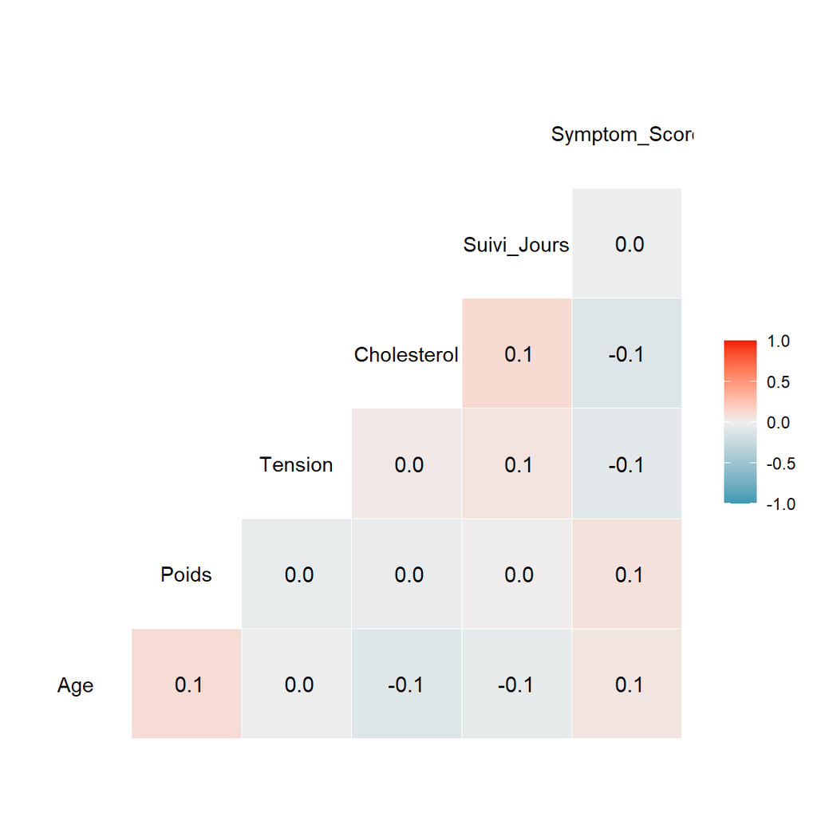

```r
GGally::ggcorr(numeric_vars, label = TRUE)
```

Interprétation :  
- Les coefficients de corrélation proches de **+1** indiquent une relation **croissante forte**,  
- proches de **-1**, une relation **décroissante forte**,  
- proches de **0**, absence de relation linéaire.

## 4.2 . Exemple : Âge vs score de symptômes

```r
cor.test(data_clean$Age, data_clean$Symptom_Score)
```

```
##
##  Pearson's product-moment correlation
##
## data:  data_clean$Age and data_clean$Symptom_Score
## t = 0.51639, df = 98, p-value = 0.6067
## alternative hypothesis: true correlation is not equal to 0
## 95 percent confidence interval:
##  -0.1458180  0.2459932
## sample estimates:
##        cor
## 0.05209209
```

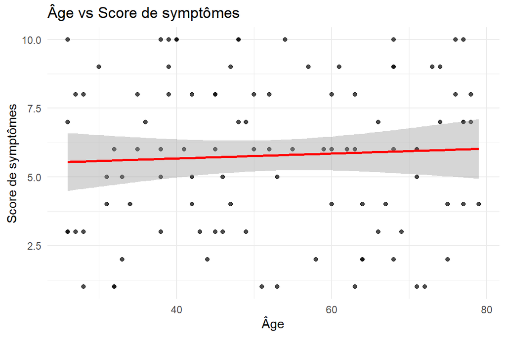

```r
ggplot(data_clean, aes(x = Age, y = Symptom_Score)) +
  geom_point(alpha = 0.7) +
  geom_smooth(method = "lm", color = "red", se = TRUE) +
  theme_minimal() +
  labs(title = "Âge vs Score de symptômes",
       x = "Âge",
       y = "Score de symptômes")
```

Interprétation (à adapter) :  
> Le coefficient de corrélation et le p-value indiquent si l’âge est significativement lié au score de symptômes.  
> Une pente positive signifie que le score augmente avec l’âge, une pente négative l’inverse.

## 4.3 . Score de symptômes selon le groupe de traitement

### 4.3.1 . Visualisation

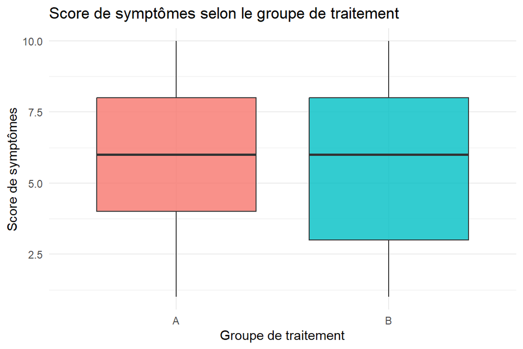

```r
ggplot(data_clean, aes(x = Groupe_Traitement, y = Symptom_Score, fill = Groupe_Traitement)) +
  geom_boxplot(alpha = 0.8) +
  theme_minimal() +
  labs(title = "Score de symptômes selon le groupe de traitement",
       x = "Groupe de traitement",
       y = "Score de symptômes") +
  theme(legend.position = "none")
```

### 4.3.2 . ANOVA (si conditions de normalité/homogénéité raisonnables)

```r
anova_model <- aov(Symptom_Score ~ Groupe_Traitement, data = data_clean)
summary(anova_model)
```

```
##                   Df Sum Sq Mean Sq F value Pr(>F)
## Groupe_Traitement  1    8.9   8.943    1.15  0.286
## Residuals         98  762.2   7.778
```

Interprétation :  
- Si le **p-value global < 0,05**, il existe une **différence significative** de score de symptômes entre au moins deux groupes.  
- Sinon, les moyennes ne diffèrent pas significativement.

## 4.4 . Score de symptômes selon le sexe

```r
t.test(Symptom_Score ~ Sexe, data = data_clean, var.equal = FALSE)
```

```
##
##  Welch Two Sample t-test
##
## data:  Symptom_Score by Sexe
## t = -0.85436, df = 77.298, p-value = 0.3955
## alternative hypothesis: true difference in means between group F and group M is not equal to 0
## 95 percent confidence interval:
##  -1.6454896  0.6573741
## sample estimates:
## mean in group F mean in group M
##        5.473684        5.967742
```

Interprétation :  
> Le test de Student permet de comparer la moyenne du score entre les sexes.  
> Si **p < 0,05**, la différence est significative.

## 4.5 . Association entre deux variables qualitatives : Sexe × Groupe de traitement

```r
tab_sexe_traitement <- table(data_clean$Sexe, data_clean$Groupe_Traitement)
tab_sexe_traitement
```

```
##
##      A  B
##   F 18 20
##   M 40 22
```

```r
chisq.test(tab_sexe_traitement)
```

```
##
##  Pearson's Chi-squared test with Yates' continuity correction
##
## data:  tab_sexe_traitement
## X-squared = 2.1835, df = 1, p-value = 0.1395
```

Interprétation :  
- Si le **p-value du χ² < 0,05**, il existe une association significative entre le sexe et le groupe de traitement.

# 5 . Analyse multivariée : régression linéaire multiple

Nous cherchons à expliquer le **score de symptômes** à partir des autres variables.

## 5.1 1 Modèle global

```r
modele_lm <- lm(
  Symptom_Score ~ Age + Sexe + Poids + Tension + Cholesterol + Groupe_Traitement + Suivi_Jours,
  data = data_clean
)

summary(modele_lm)
```

```
##
## Call:
## lm(formula = Symptom_Score ~ Age + Sexe + Poids + Tension + Cholesterol +
##     Groupe_Traitement + Suivi_Jours, data = data_clean)
##
## Residuals:
##     Min      1Q  Median      3Q     Max
## -5.4671 -2.1344  0.3576  2.2278  5.3745
##
## Coefficients:
##                     Estimate Std. Error t value Pr(>|t|)
## (Intercept)         7.639513   4.099782   1.863   0.0656 .
## Age                 0.013349   0.018607   0.717   0.4749
## SexeM               0.601369   0.633272   0.950   0.3448
## Poids               0.011142   0.019671   0.566   0.5725
## Tension            -0.008697   0.016311  -0.533   0.5952
## Cholesterol        -0.011950   0.010698  -1.117   0.2669
## Groupe_TraitementB -0.584905   0.592469  -0.987   0.3261
## Suivi_Jours         0.007003   0.086156   0.081   0.9354
## ---
## Signif. codes:  0 '***' 0.001 '**' 0.01 '*' 0.05 '.' 0.1 ' ' 1
##
## Residual standard error: 2.83 on 92 degrees of freedom
## Multiple R-squared:  0.04451,    Adjusted R-squared:  -0.02819
## F-statistic: 0.6123 on 7 and 92 DF,  p-value: 0.7444
```

Interprétation (générale) :  
- Le **R²** indique la proportion de la variabilité du score expliquée par le modèle.  
- Chaque coefficient représente l’effet **moyen** de la variable, **à variables constantes**.  
- Si le p-value d’un coefficient est **< 0,05**, l’effet est statistiquement significatif.

## 5.2 . Coefficients sous forme de tableau propre

```r
tidy(modele_lm, conf.int = TRUE)
```

```
## # A tibble: 8 × 7
##   term               estimate std.error statistic p.value conf.low conf.high
##   <chr>                 <dbl>     <dbl>     <dbl>   <dbl>    <dbl>     <dbl>
## 1 (Intercept)         7.64       4.10      1.86    0.0656  -0.503   15.8
## 2 Age                 0.0133     0.0186    0.717   0.475   -0.0236   0.0503
## 3 SexeM               0.601      0.633     0.950   0.345   -0.656    1.86
## 4 Poids               0.0111     0.0197    0.566   0.572   -0.0279   0.0502
## 5 Tension            -0.00870    0.0163   -0.533   0.595   -0.0411   0.0237
## 6 Cholesterol        -0.0120     0.0107   -1.12    0.267   -0.0332   0.00930
## 7 Groupe_TraitementB -0.585      0.592    -0.987   0.326   -1.76     0.592
## 8 Suivi_Jours         0.00700    0.0862    0.0813  0.935   -0.164    0.178
```

## 5.3 . Vérification des hypothèses du modèle

### 5.3.1 . Résidus vs valeurs ajustées (homoscédasticité)

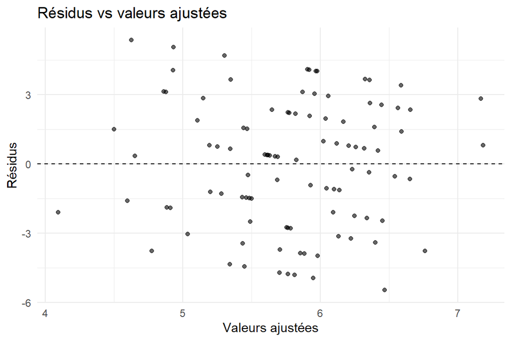

```r
ggplot(data.frame(
  fitted = fitted(modele_lm),
  resid = resid(modele_lm)
), aes(x = fitted, y = resid)) +
  geom_point(alpha = 0.6) +
  geom_hline(yintercept = 0, linetype = "dashed") +
  theme_minimal() +
  labs(title = "Résidus vs valeurs ajustées",
       x = "Valeurs ajustées",
       y = "Résidus")
```

Interprétation :  
> On recherche une **dispersion aléatoire** des résidus autour de 0.  
> Des motifs particuliers (courbe, entonnoir…) peuvent indiquer une violation de l’hypothèse d’homoscédasticité.